# examples

The `trophic` package has several different uses. These are some examples of possible use cases. Please feel free to contribute your own additions (see here for details).

## example: predicting biomass of a high-order predator with known food web

This is a simple example where we have a known (or assumed) food web and some estimates of trophic transfer efficiencies. The food web additionally contains information on the relative dominance of consumers over potential competitors. This information is captured in the objects `food_web` (a lower triangular matrix of zeros and ones), `efficiency_mean` (a series of proportions for trophic transfer efficiencies), and `dominance_matrix` (a matrix of relative values for each consumer). In food webs in `trophic`, we assume that “rows eat columns”, that is, a value in a given cell indicates that the node in that row eats the node in that column.

Example fixed food web

|  | decapod.crustaceans | small.fish | carp | reptiles | mammals | birds | large.fish |
| --- | --- | --- | --- | --- | --- | --- | --- |
| decapod.crustaceans | 0 | 0 | 0 | 0 | 0 | 0 | 0 |
| small.fish | 0 | 0 | 0 | 0 | 0 | 0 | 0 |
| carp | 0 | 0 | 0 | 0 | 0 | 0 | 0 |
| reptiles | 0 | 1 | 0 | 0 | 0 | 0 | 0 |
| mammals | 1 | 0 | 0 | 0 | 0 | 0 | 0 |
| birds | 1 | 1 | 0 | 0 | 0 | 0 | 0 |
| large.bodied.native.fish | 1 | 1 | 0 | 0 | 1 | 1 | 0 |

Example efficiency matrix

|  | decapod.crust | small.fish | carp | reptiles | mammals | birds | large.bodied.fish |
| --- | --- | --- | --- | --- | --- | --- | --- |
| decapod.crust | 0.1 | 0.15 | 0.12 | 0.09 | 0.05 | 0.07 | 0.04 |
| small.fish | 0.1 | 0.15 | 0.12 | 0.09 | 0.05 | 0.07 | 0.04 |
| carp | 0.1 | 0.15 | 0.12 | 0.09 | 0.05 | 0.07 | 0.04 |
| reptiles | 0.1 | 0.15 | 0.12 | 0.09 | 0.05 | 0.07 | 0.04 |
| mammals | 0.1 | 0.15 | 0.12 | 0.09 | 0.05 | 0.07 | 0.04 |
| birds | 0.1 | 0.15 | 0.12 | 0.09 | 0.05 | 0.07 | 0.04 |
| large.bodied.fish | 0.1 | 0.15 | 0.12 | 0.09 | 0.05 | 0.07 | 0.04 |

Example dominance matrix

|  | decapod.crustaceans | small.fish | carp | reptiles | mammals | birds | large.fish |
| --- | --- | --- | --- | --- | --- | --- | --- |
| decapod.crustaceans | 0 | 0 | 0 | 0 | 0 | 0 | 0 |
| small.fish | 0 | 0 | 0 | 0 | 0 | 0 | 0 |
| carp | 0 | 0 | 0 | 0 | 0 | 0 | 0 |
| reptiles | 0 | 2 | 0 | 0 | 0 | 0 | 0 |
| mammals | 1 | 0 | 0 | 0 | 0 | 0 | 0 |
| birds | 1 | 4 | 0 | 0 | 0 | 0 | 0 |
| large.bodied.native.fish | 8 | 4 | 0 | 0 | 12 | 4 | 0 |

If transfer efficiencies are unknown, they can be assumed to be 10% (0.1) by calling `build_trophic_dynamics()` with `efficiency_matrix = NULL`. Similarly, if dominance values are unknown, they can be assumed to be equal (all consumers will get an equal share of a shared resource) by setting `dominance_matrix = NULL` in the `build_trophic_dynamics()` function.

We additionally have estimates of primary production (`production_mean` and `production_sd`) that we use to initialise the food web. These values are required for all models in `trophic`. Estimates of primary production can be collated into a `trophic` object with the `build_primary_producers()` function, which can take named vectors of means and standard deviations. Alternatively, if `production_mean` and `production_sd` are not named, the model will assume that production values correspond to the first columns in the food web (one column for each value in `production_mean` and `production_sd`).

```r
# load trophic package
library(trophic)

# prepare food web, transfer efficiencies, and dominance matrix
example_fw <- build_food_web(interaction_matrix = food_web)
example_eps <- build_efficiency_matrix(efficiency_mean = efficiency_mean,
                                       efficiency_sd = 0.05)
example_doms <- build_dominance_matrix(dominance = dominance_matrix)

# build primary producers object
example_pp <- build_primary_producers(production_mean = production_mean,
                                      production_sd = production_sd)

# collate trophic_dynamics object
example_trophic <- build_trophic_dynamics(food_web = example_fw,
                                          efficiency_matrix = example_eps,
                                          dominance_matrix = example_doms)
```

The collated `trophic_dynamics` and `primary_producers` objects can be used to predict production at any node in the food web with the `estimate_production()` function. This function takes two additional arguments: `stochastic` and `nsim`. The `stochastic` argument specifies which components of the projection should be estimated with uncertainty. These can be any combination of `food_web`, `efficiency`, and `primary_production`. If `stochastic = NULL` or `stochastic = c("random_text")` then the production estimates will be simulated without noise (based on mean values in `trophic_dynamics` and `primary_producers`).

```r
# predict production of all nodes
predicted_production <- estimate_production(trophic_dynamics = example_trophic,
                                            primary_producers = example_pp,
                                            stochastic = c("efficiency",
                                                           "primary_production"))
```

The `pb_ratio` object can take three forms: fixed, gradient, or stochastic. A fixed `pb_ratio` will be set to the midpoint of the `range` argument, and conversions will not include any uncertainty. A gradient `pb_ratio` will take a set number of values in `range`, with the number of values determined by the `length` argument to `build_pb_ratio()`. The `estimate_biomass()` function will generate one set of `nsim` biomass values for each value in the `pb_ratio` gradient. A stochastic `pb_ratio` will sample values in `range` according to specified probabilities (the `probs` argument in `build_pb_ratio()`). The `estimate_biomass()` function will generate one set of `nsim` biomass values, where each of the `nsim` production values is assigned a random P:B value.

```r
# create a P:B ratio object to link production to biomass
example_pb <- build_pb_ratio(range = c(0.25, 5.75), type = "fixed")

# use P:B ratio to estimate biomass from production
predicted_biomass <- estimate_biomass(production_estimates = predicted_production,
                                      pb_ratio = example_pb)
```

There are several helper functions to summarise the information generated by `estimate_production` or `estimate_biomass`. For example, it is possible to `plot()` the values for all nodes or a subset of nodes, where subsets can be based on row indexing or on node names. It is possible to extract values for any or all nodes, summarised by a function of your choice, using the `extract_nodes()` function.

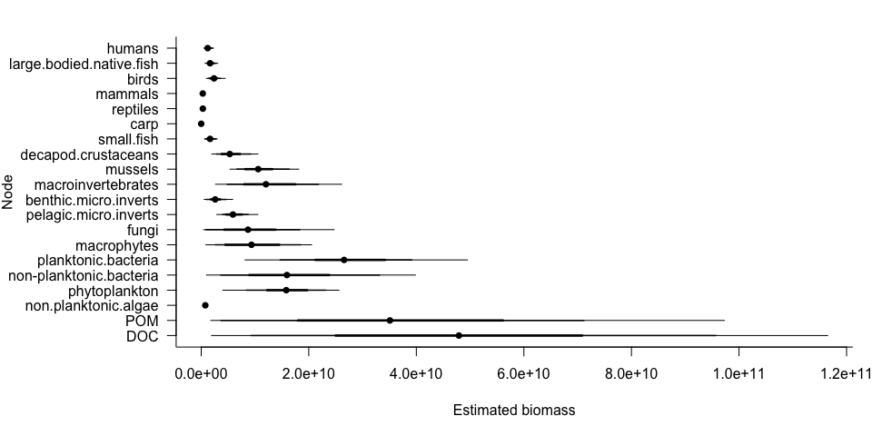

```r
# plot biomass for all nodes
plot(predicted_biomass)
```

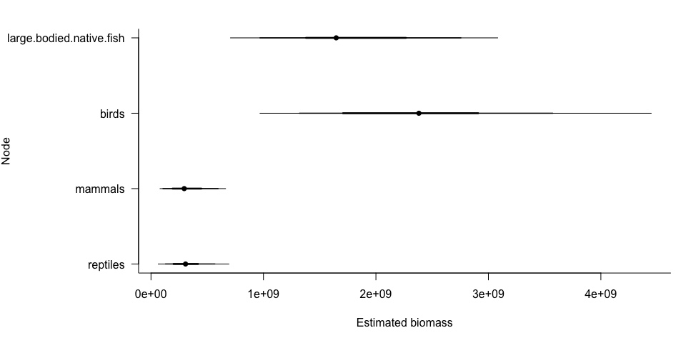

```r
# plot biomass for nodes of interest
plot(predicted_biomass, nodes = c(16:19))
```

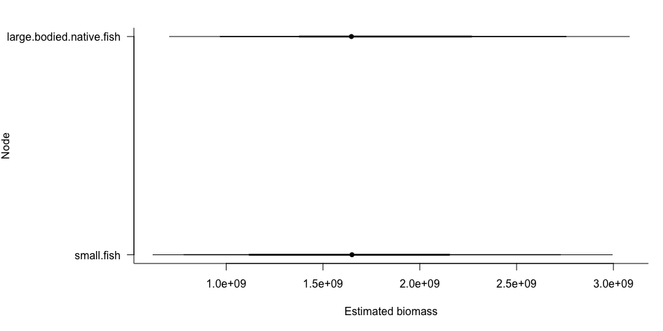

```r
# plot biomass for nodes of interest
plot(predicted_biomass, nodes = c("small.fish", "large.bodied.native.fish"))
```

```r
# extract mean of biomass for a single node of interest
fish_biomass_mean <- extract_nodes(predicted_biomass, nodes = "large.bodied.native.fish",
                                   FUN = mean)

# extract quantiles of biomass for a single node of interest
fish_biomass_quantiles <- extract_nodes(predicted_biomass, nodes = "large.bodied.native.fish",
                                        FUN = quantile, p = c(0.025, 0.1, 0.25, 0.5, 0.75, 0.9, 0.975))
```

## example: predicting biomass of a high-order predator with uncertain food web

We can repeat the previous example but account for uncertainty in the stucture of the food web. In this case, the interaction matrix takes values in [0, 1] rather than being equal exactly to zero or one. For example, the example food web shown above can be altered so that links have a probability rather than definitely being present or absent.

Example stochastic food web

|  | decapod.crustaceans | small.fish | carp | reptiles | mammals | birds | large.fish |
| --- | --- | --- | --- | --- | --- | --- | --- |
| decapod.crustaceans | 0.00 | 0.00 | 0 | 0 | 0.00 | 0.00 | 0 |
| small.fish | 0.00 | 0.00 | 0 | 0 | 0.00 | 0.00 | 0 |
| carp | 0.00 | 0.00 | 0 | 0 | 0.00 | 0.00 | 0 |
| reptiles | 0.00 | 0.38 | 0 | 0 | 0.00 | 0.00 | 0 |
| mammals | 0.94 | 0.00 | 0 | 0 | 0.00 | 0.00 | 0 |
| birds | 0.80 | 0.96 | 0 | 0 | 0.00 | 0.00 | 0 |
| large.bodied.native.fish | 0.92 | 0.80 | 0 | 0 | 0.41 | 0.86 | 0 |

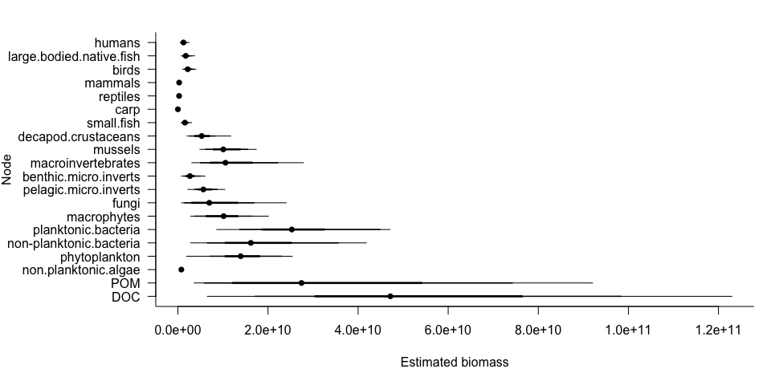

```r
# load trophic package
library(trophic)

# prepare food web, transfer efficiencies, and dominance matrix
stoch_food_web <- food_web * runif(length(food_web), min = 0, max = 1)
example_fw <- build_food_web(interaction_matrix = stoch_food_web)
example_eps <- build_efficiency_matrix(efficiency_mean = efficiency_mean,
                                       efficiency_sd = 0.05)
example_doms <- build_dominance_matrix(dominance = dominance_matrix)

# build primary producers object
example_pp <- build_primary_producers(production_mean = production_mean,
                                      production_sd = production_sd)

# collate trophic_dynamics object
example_trophic <- build_trophic_dynamics(food_web = example_fw,
                                          efficiency_matrix = example_eps,
                                          dominance_matrix = example_doms)

# predict production of all nodes
predicted_production <- estimate_production(trophic_dynamics = example_trophic,
                                            primary_producers = example_pp,
                                            stochastic = c("efficiency",
                                                           "primary_production"))

# create a P:B ratio object to link production to biomass
example_pb <- build_pb_ratio(range = c(0.25, 5.75), type = "fixed")

# use P:B ratio to estimate biomass from production
predicted_biomass <- estimate_biomass(production_estimates = predicted_production,
                                      pb_ratio = example_pb)

# plot biomass for all nodes
plot(predicted_biomass)
```

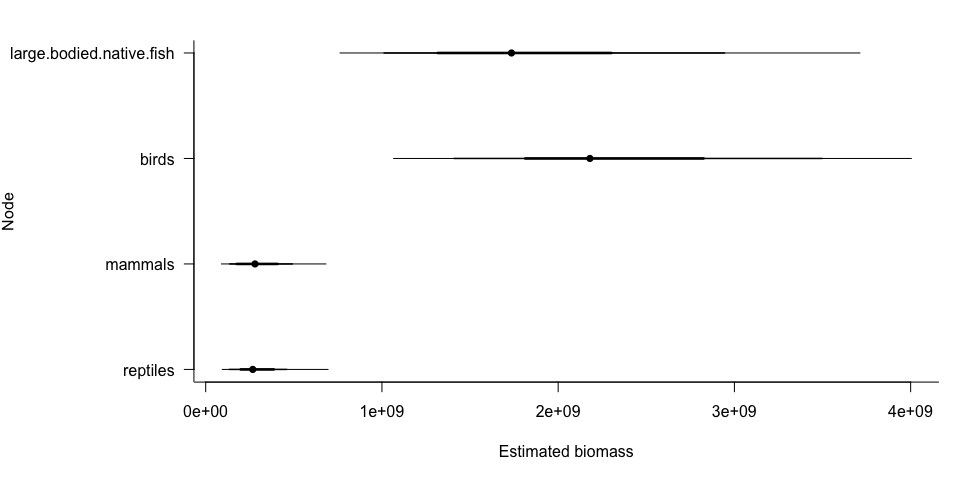

```r
# plot biomass for nodes of interest
plot(predicted_biomass, nodes = c(16:19))
```

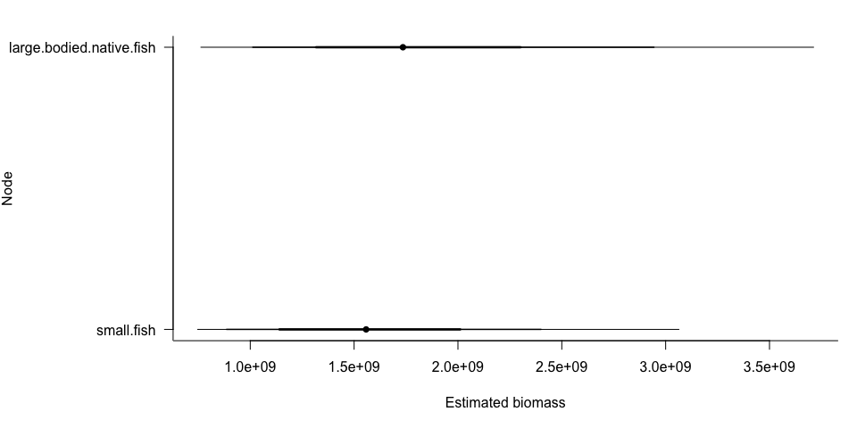

```r
# plot biomass for nodes of interest
plot(predicted_biomass, nodes = c("small.fish", "large.bodied.native.fish"))
```

```r
# extract mean of biomass for a single node of interest
fish_biomass_mean <- extract_nodes(predicted_biomass, nodes = "large.bodied.native.fish",
                                   FUN = mean)

# extract quantiles of biomass for a single node of interest
fish_biomass_quantiles <- extract_nodes(predicted_biomass, nodes = "large.bodied.native.fish",
                                        FUN = quantile, p = c(0.025, 0.1, 0.25, 0.5, 0.75, 0.9, 0.975))
```